# tidy-model

## Introduction

This R Markdown document demonstrates my abilities to use models for data analysis using a data set collected on crickets.

## What is that sound?

In this report, we examine what factors predict a cricket’s chirp rate.

```
##              species        temp            rate
##  O. exclamationis:14   Min.   :17.20   Min.   : 44.30
##  O. niveus       :17   1st Qu.:20.80   1st Qu.: 59.45
##                        Median :24.00   Median : 76.20
##                        Mean   :23.76   Mean   : 72.89
##                        3rd Qu.:26.35   3rd Qu.: 85.25
##                        Max.   :30.40   Max.   :101.70
```

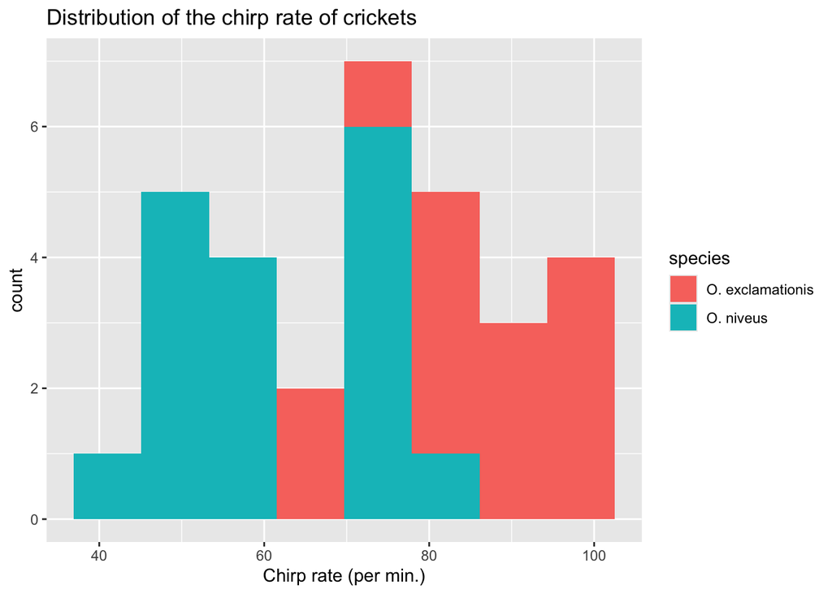

There is 14 exclamations and 17 niveus. The minimum temperature is 17.20, and the maximum temperature is 30.40. The mean rate of chirping is 72.89

## Temperature affects chirp rate

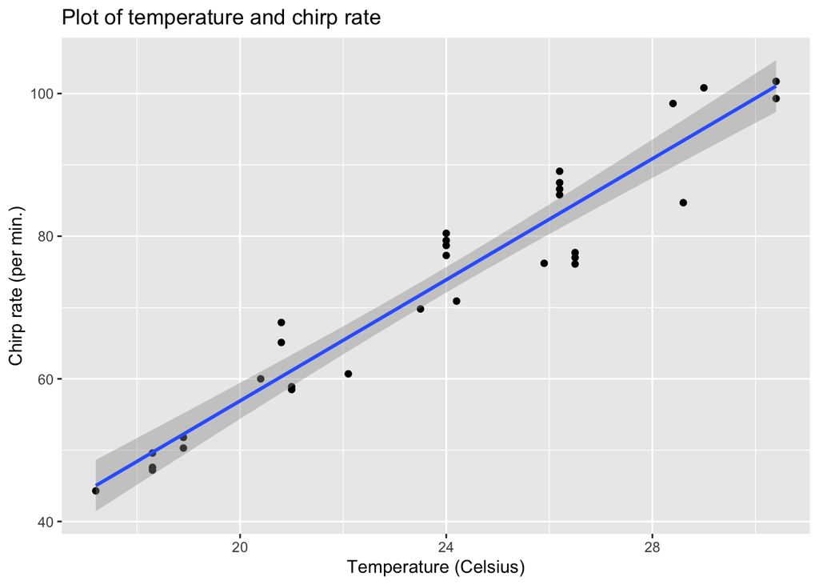

```
##
## Call:
## lm(formula = rate ~ temp, data = crickets)
##
## Residuals:
##     Min      1Q  Median      3Q     Max
## -8.7044 -2.5789 -0.4466  4.5353  7.5916
##
## Coefficients:
##             Estimate Std. Error t value Pr(>|t|)
## (Intercept) -27.9476     5.5937  -4.996 2.56e-05 ***
## temp          4.2431     0.2325  18.251  < 2e-16 ***
## ---
## Signif. codes:  0 '***' 0.001 '**' 0.01 '*' 0.05 '.' 0.1 ' ' 1
##
## Residual standard error: 4.868 on 29 degrees of freedom
## Multiple R-squared:  0.9199, Adjusted R-squared:  0.9171
## F-statistic: 333.1 on 1 and 29 DF,  p-value: < 2.2e-16
```

Based on a scatter plot of temperature and chirping and a correlation test, it seems that as temperature increases one degree, the rate of chirping increases about 4.2 chirps per minute.

## Species-specific effects of temperature on chirping

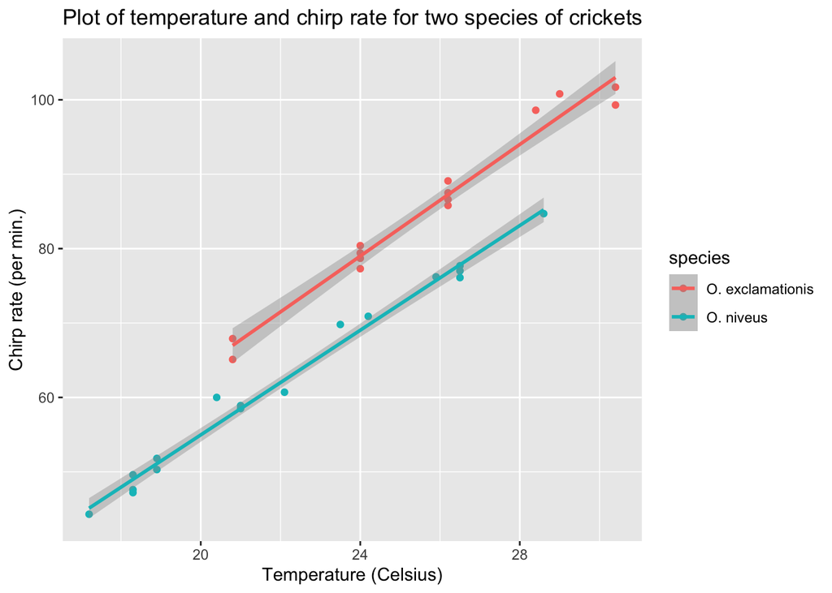

```
##
## Call:
## lm(formula = rate ~ temp + species, data = crickets)
##
## Residuals:
##     Min      1Q  Median      3Q     Max
## -3.0128 -1.1296 -0.3912  0.9650  3.7800
##
## Coefficients:
##                   Estimate Std. Error t value Pr(>|t|)
## (Intercept)       -7.21091    2.55094  -2.827  0.00858 **
## temp               3.60275    0.09729  37.032  < 2e-16 ***
## speciesO. niveus -10.06529    0.73526 -13.689 6.27e-14 ***
## ---
## Signif. codes:  0 '***' 0.001 '**' 0.01 '*' 0.05 '.' 0.1 ' ' 1
##
## Residual standard error: 1.786 on 28 degrees of freedom
## Multiple R-squared:  0.9896, Adjusted R-squared:  0.9888
## F-statistic:  1331 on 2 and 28 DF,  p-value: < 2.2e-16
```

## Interactions

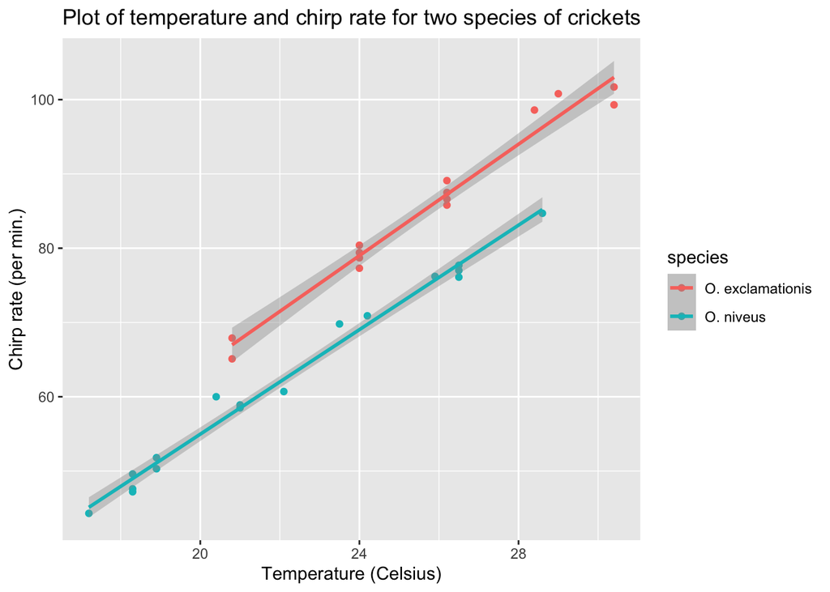

```
##
## Call:
## lm(formula = rate ~ temp + species + temp:species, data = crickets)
##
## Residuals:
##     Min      1Q  Median      3Q     Max
## -3.7031 -1.3417 -0.1235  0.8100  3.6330
##
## Coefficients:
##                       Estimate Std. Error t value Pr(>|t|)
## (Intercept)           -11.0408     4.1515  -2.659    0.013 *
## temp                    3.7514     0.1601  23.429   <2e-16 ***
## speciesO. niveus       -4.3484     4.9617  -0.876    0.389
## temp:speciesO. niveus  -0.2340     0.2009  -1.165    0.254
## ---
## Signif. codes:  0 '***' 0.001 '**' 0.01 '*' 0.05 '.' 0.1 ' ' 1
##
## Residual standard error: 1.775 on 27 degrees of freedom
## Multiple R-squared:  0.9901, Adjusted R-squared:  0.989
## F-statistic: 898.9 on 3 and 27 DF,  p-value: < 2.2e-16
```

```
## Analysis of Variance Table
##
## Model 1: rate ~ temp + species
## Model 2: rate ~ temp + species + temp:species
##   Res.Df    RSS Df Sum of Sq     F Pr(>F)
## 1     28 89.350
## 2     27 85.074  1    4.2758 1.357 0.2542
```

## Load the data

```
## # A tibble: 6 × 10
##   carat cut       color clarity depth table price     x     y     z
##   <dbl> <ord>     <ord> <ord>   <dbl> <dbl> <int> <dbl> <dbl> <dbl>
## 1  0.23 Ideal     E     SI2      61.5    55   326  3.95  3.98  2.43
## 2  0.21 Premium   E     SI1      59.8    61   326  3.89  3.84  2.31
## 3  0.23 Good      E     VS1      56.9    65   327  4.05  4.07  2.31
## 4  0.29 Premium   I     VS2      62.4    58   334  4.2   4.23  2.63
## 5  0.31 Good      J     SI2      63.3    58   335  4.34  4.35  2.75
## 6  0.24 Very Good J     VVS2     62.8    57   336  3.94  3.96  2.48
```

## Distribution of the price

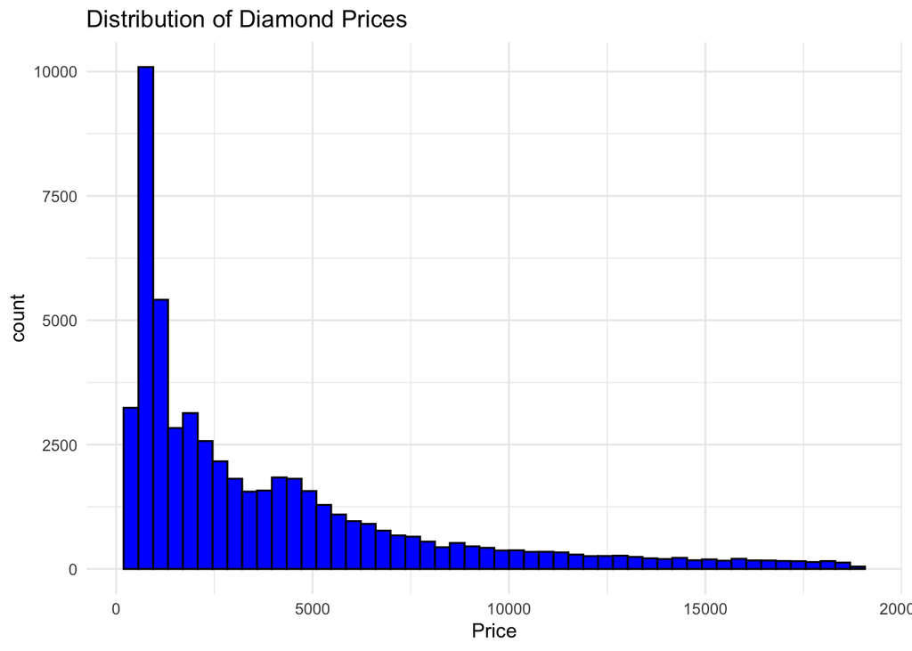

## Correaltion Between Price and Carrat

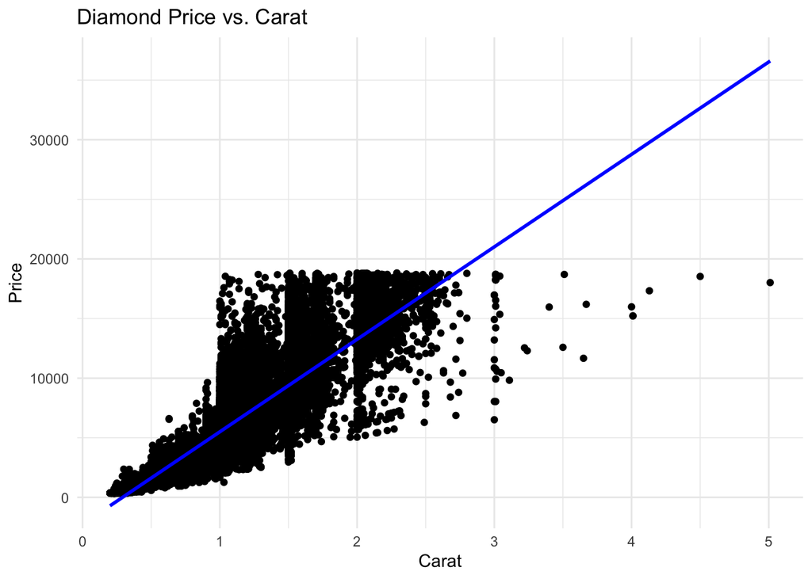

The carat of the diamond does not fully dictate the price of the diamond, as other factors such as cut, clarity, and color can also determine its value

## Price Distribution by Diamond Cut and Carrat

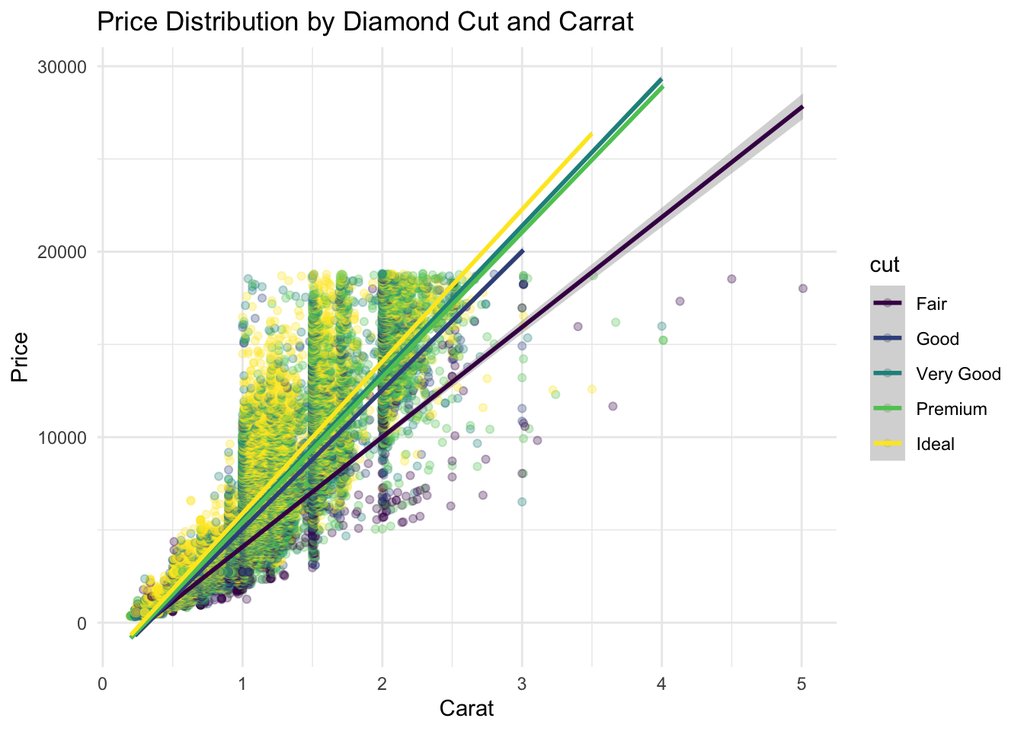

```
##
## Call:
## lm(formula = price ~ carat + cut + clarity, data = diamonds)
##
## Residuals:
##      Min       1Q   Median       3Q      Max
## -16842.5   -636.4   -114.3    474.8  11238.6
##
## Coefficients:
##              Estimate Std. Error  t value Pr(>|t|)
## (Intercept) -3187.540     14.475 -220.208   <2e-16 ***
## carat        8472.026     12.615  671.584   <2e-16 ***
## cut.L         713.804     22.511   31.709   <2e-16 ***
## cut.Q        -334.503     19.828  -16.871   <2e-16 ***
## cut.C         188.482     17.218   10.947   <2e-16 ***
## cut^4           1.663     13.794    0.121   0.9040
## clarity.L    4011.681     33.931  118.231   <2e-16 ***
## clarity.Q   -1821.922     31.870  -57.167   <2e-16 ***
## clarity.C     917.658     27.313   33.598   <2e-16 ***
## clarity^4    -430.047     21.831  -19.699   <2e-16 ***
## clarity^5     257.141     17.821   14.429   <2e-16 ***
## clarity^6      26.909     15.539    1.732   0.0833 .
## clarity^7     186.742     13.685   13.646   <2e-16 ***
## ---
## Signif. codes:  0 '***' 0.001 '**' 0.01 '*' 0.05 '.' 0.1 ' ' 1
##
## Residual standard error: 1281 on 53927 degrees of freedom
## Multiple R-squared:  0.8969, Adjusted R-squared:  0.8969
## F-statistic: 3.911e+04 on 12 and 53927 DF,  p-value: < 2.2e-16
```

[output not shown]

In this graph, we can see that Ideal is the best type of cut to get, as it tends to cost the most, even when the carat is lower compared to another diamond with a different cut